# Project 2: Kings County Housing Data

Apr 23, 2016

# 1 Introduction

King County, WA is a district in around Seattle, WA. There are houses being sold within that district, and prices vary depending on different factors. Modeling the relationship between prices of the houses sold and other data would assist the reader in understanding how much a house could cost in King County, WA. The variables that are recorded in the data are explained by the [King County Department of Assessement](http://your.kingcounty.gov/assessor/eRealProperty/ResGlossaryOfTerms.html).

The analysis and model used in this paper suggest that the price of a house in King County is related to many factors aside from the very basics: number of bedrooms, bathrooms, and so forth. Individuals looking at houses in King County can use this model to predict the price of it. Even individuals looking to price a house to sell can use this model to see what the best pricing is what a house with specific criteria.

[figure not shown]

# 2 Methods

## 2.1 Data Collection

Data used in this paper was originally downloaded from

https://raw.githubusercontent.com/STAT-ATA-ASU/STT3851Spring2016/gh-pages/Data/housedata.csv

March 31, 2016, and again April 23, 2016, using the `R` programming language (R Core Team 2015). It is not clear from the available information how, from whom, or when the data was collected, nor is it clear what entity or organization did the collecting.

None of the variables are removed from the data.

## 2.2 Exploratory Analysis

Exploratory analysis was performed by implimenting cross validation and observing the mean cross validation errors for a number of different variables that use the training data. Many additional variables looking into the relationship between two variables were added into the model in order to select appropriate variables. These additions were choosen by using a scatterplot to see if a suspected relationship existed between two different variables. Variables such as the id number of the house and date when the house is on the market were not included in the variable selection.

## 2.3 Statistical Modeling

Cross Validating with K folds as described in James et al. (2013) was used to develop a model to predict the price of a house in King County, WA.

## 2.4 Reproducibility

All analyses performed in this paper can be reproduced by running the original `.Rmd` file with RStudio, assuming the link to the original data remains current and the contents thereof remain unchanged. The `R` packages `car` (Fox and Weisberg 2015), `ggplot2` (Wickham and Chang 2016), `knitr` (Xie 2016a), `rmarkdown` (Allaire et al. 2016), `leaps`(Lumley 2009),and `bookdown` (Xie 2016b) will need to be installed on the user’s computer. Since `bookdown` is being actively developed and is not yet on [CRAN](https://cran.r-project.org/), you will need to install `bookdown` from [GitHub](https://github.com) by typing the following at the `R` prompt:

```r
devtools::install_github("rstudio/bookdown")
```

# 3 Results

The data used to develop the final model includes information on the grade of the house, zipcode, relationship between zipcode and the amount of living space in the house measured in square feet, the number of bedrooms, the amount of living space in the house, the amount of living space in the 15 neighboring houses, the amount of lot space to the house, the amount of lot space to the 15 neighboring hosues, number of bathrooms in the house, condition of the house, latitude and longitude, the square footage of space above the basement floor, the year the house was built, the year the house was renovated, the realtionship between the year the house was built and renovated, whether there was a waterfront, the relationship between having a waterfront and the number of floors a house has, the relationship between the amount of living space in the house and the number of bedrooms, the relationship between the amount of living space in the house and the amount of living space above the basement floor, the relationship between the amount of living space in the house and the amount of lot space to the house, the relationship between the amount of living space in the house and the amount of lot space for the 15 neighboring houses, the relationship between the number of bedrooms and bathrooms, and the relationship between the square footage above the basement floor and the view. Variables were added based on scatterplots and using k-fold cross validation.

Although the final model includes variables that may measure similar quantities (confounding), the highest variance inflation factors were 3.55, 8.23, and 2.85 for the variables `sqft_living^2`, `sqft_above^2`, and `sqft_living:sqft_above` respectively. All other variance inflation factors were less than 10, suggesting multicollinearity is not a significant problem with the final model (Fox, Weisberg, and Fox (2011) and Kutner et al. (2005)).

The final model used was

$\beta_{12} \text{long} + \beta_{13} \text{sqft_above}^2 + \beta_{14} \text{yr_renovated} +$

$\beta_{15} \text{yr_built} + \beta_{16} \text{waterfront} + \beta_{17} \text{waterfront:floors}$

$+ \beta_{18} \text{sqft_living:bedrooms} + \beta_{19} \text{sqft_living:sqft_above} +$

$\beta_{20} \text{sqft_living:sqft_lot} + \beta_{21} \text{sqft_living15:sqft_lot15} +$

$\beta_{22} \text{bedrooms:bathrooms} + \beta_{23} \text{yr_renovated:yr_built} +$

$\beta_{24} \text{sqft_above:view} +\varepsilon$

The variables `zipcode` and `grade` are factors for price while variables such as `bedrooms:bathrooms` are the relationship of two variables. The error term $\varepsilon$ is assumed to follow a normal distribution with mean 0 and constant variance. A graph of the residuals versus the fitted model, shown in Figure 3.1, shows a very skewed variance towards the left of the range of the fitted values, suggesting the fitted model needs more work to meet the assumptions required for inferential techniques to work with ordinary least squares.

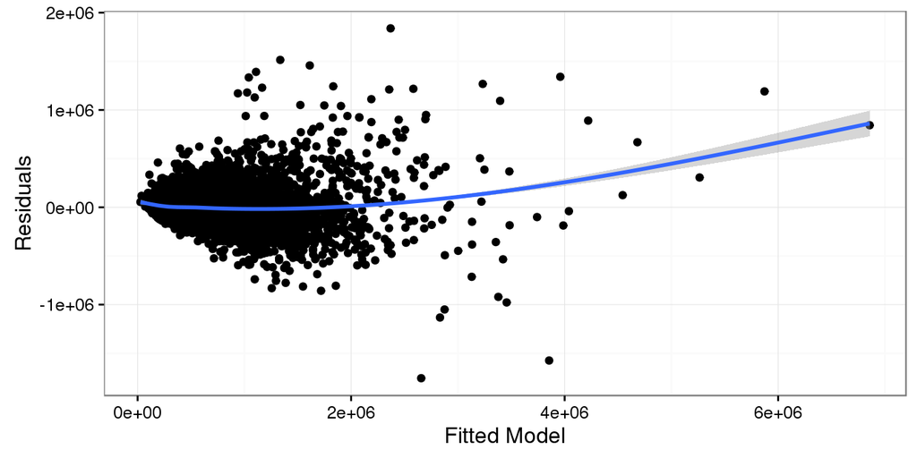

Figure 3.1: Residuals versus fitted model

Table 3.1: ANOVA table for the full model fit using ordinary least squares

|  | Df | Sum Sq | Mean Sq | F value | Pr(>F) |
| --- | --- | --- | --- | --- | --- |
| grade | 11 | 1.238791e+15 | 1.126174e+14 | 7164.8200 | 0.0000 |
| zipcode | 69 | 4.465345e+14 | 6.471515e+12 | 411.7237 | 0.0000 |
| bedrooms | 1 | 2.965500e+13 | 2.965500e+13 | 1886.6782 | 0.0000 |
| sqft_living | 1 | 1.453222e+14 | 1.453222e+14 | 9245.5297 | 0.0000 |
| I(sqft_living^2) | 1 | 1.589157e+13 | 1.589157e+13 | 1011.0361 | 0.0000 |
| sqft_living15 | 1 | 4.933567e+12 | 4.933567e+12 | 313.8781 | 0.0000 |
| sqft_lot | 1 | 8.361938e+11 | 8.361938e+11 | 53.1994 | 0.0000 |
| sqft_lot15 | 1 | 1.741287e+11 | 1.741287e+11 | 11.0782 | 0.0009 |
| I(bathrooms^2) | 1 | 8.183397e+11 | 8.183397e+11 | 52.0635 | 0.0000 |
| condition | 4 | 1.165977e+13 | 2.914942e+12 | 185.4513 | 0.0000 |
| lat | 1 | 7.371780e+10 | 7.371780e+10 | 4.6900 | 0.0304 |
| long | 1 | 1.104170e+12 | 1.104170e+12 | 70.2483 | 0.0000 |
| I(sqft_above^2) | 1 | 1.546338e+11 | 1.546338e+11 | 9.8379 | 0.0017 |
| yr_renovated | 1 | 7.366096e+11 | 7.366096e+11 | 46.8638 | 0.0000 |
| yr_built | 1 | 8.067931e+12 | 8.067931e+12 | 513.2892 | 0.0000 |
| waterfront | 1 | 7.583109e+13 | 7.583109e+13 | 4824.4439 | 0.0000 |
| zipcode:sqft_living | 69 | 1.014712e+14 | 1.470597e+12 | 93.5607 | 0.0000 |
| waterfront:floors | 2 | 2.658792e+12 | 1.329396e+12 | 84.5774 | 0.0000 |
| sqft_living:bedrooms | 1 | 2.990788e+12 | 2.990788e+12 | 190.2767 | 0.0000 |
| sqft_living:sqft_above | 1 | 3.759561e+11 | 3.759561e+11 | 23.9187 | 0.0000 |
| sqft_living:sqft_lot | 1 | 9.564128e+10 | 9.564128e+10 | 6.0848 | 0.0136 |
| sqft_living15:sqft_lot15 | 1 | 1.289835e+12 | 1.289835e+12 | 82.0605 | 0.0000 |
| bedrooms:bathrooms | 1 | 5.206264e+10 | 5.206264e+10 | 3.3123 | 0.0688 |
| yr_renovated:yr_built | 1 | 1.189106e+12 | 1.189106e+12 | 75.6520 | 0.0000 |
| sqft_above:view | 1 | 1.457712e+13 | 1.457712e+13 | 927.4101 | 0.0000 |
| Residuals | 17208 | 2.704771e+14 | 1.571810e+10 | NA | NA |

# 4 Conclusions

This model needs more work put into it. Although the over all model has a residual standard error of 125400 and a $R^2_{adj}$ value of 0.885 , the number of variables that seem to have high variance factors and higher p-values than $2e-16$ shows that the model needs refinement. The scatterplots of individual variables to the price of a house seemed promising that the variables and relationships between variables chosen would create a fairly decent model when using cross validation with k folds to help further select the best variables. Changes in the housing market conditions can hinder the accuracy of this model when using it to predict prices of houses outside the time period in which the model is created.

# 5 References

Allaire, JJ, Joe Cheng, Yihui Xie, Jonathan McPherson, Winston Chang, Jeff Allen, Hadley Wickham, Aron Atkins, and Rob Hyndman. 2016. *Rmarkdown: Dynamic Documents for R*. http://rmarkdown.rstudio.com.

Fox, John, and Sanford Weisberg. 2015. *Car: Companion to Applied Regression*. http://CRAN.R-project.org/package=car.

Fox, John, Sanford Weisberg, and John Fox. 2011. *An R Companion to Applied Regression*. 2nd ed. Thousand Oaks, Calif: SAGE Publications.

James, Gareth, Daniela Witten, Trevor Hastie, and Robert Tibshirani. 2013. *Introduction to Statistical Learning*. New York: Springer Science+Business Media New York. http://www-bcf.usc.edu/ gareth/ISL/.

Kutner, Michael H, Chris Nachtsheim, John Neter, and William Li. 2005. *Applied Linear Statistical Models*. Boston: McGraw-Hill Irwin.

Lumley, Thomas. 2009. *Leaps: Regression Subset Selection*. http://CRAN.R-project.org/package=leaps.

R Core Team. 2015. *R: A Language and Environment for Statistical Computing*. Vienna, Austria: R Foundation for Statistical Computing. https://www.R-project.org/.

Wickham, Hadley, and Winston Chang. 2016. *Ggplot2: An Implementation of the Grammar of Graphics*. http://CRAN.R-project.org/package=ggplot2.

Xie, Yihui. 2016a. *Knitr: A General-Purpose Package for Dynamic Report Generation in R*. http://yihui.name/knitr/.

———. 2016b. *Bookdown: Authoring Books with R Markdown*. https://github.com/rstudio/bookdown.